# PolyIC resazurin testing

AS Huffmyer

2024

This script analyzes tests and trials of resazurin assays for the PolyIC seed project.

From this testing we need to try a few things:

1. Run the assays for a longer period of time (6 h)
2. Run the assay at a lower temperature to maintain >50% mortality by the end of the 4 hour period at least with less at the 24 hour time point

# Set up

Set up workspace, set options, and load required packages.

```r
knitr::opts_chunk$set(echo = TRUE, warning = FALSE, message = FALSE)
```

Load libraries.

```r
library(MASS)
library(tidyverse)
library(ggplot2)
library(readxl)
library(cowplot)
library(lme4)
library(lmerTest)
library(car)
library(effects)
library(emmeans)
```

# Volume testing

We first tested the signal intensity using 100, 200, or 300 µL resazurin working stock.

## Load data

```r
# Set the folder path
folder_path <- "data/resazurin/plate_files/volume-testing/"  # Replace with your folder path

# List all Excel files in the folder
file_list <- list.files(path = folder_path, pattern = "\\.xls$", full.names = TRUE)

# Check if any files are found
if (length(file_list) == 0) {
  stop("No Excel files found in the specified folder. Check the folder path or file extension.")
}

# Initialize an empty list to store data frames
data_list <- list()

# Loop through each file and load the data
for (file in file_list) {
  # Ensure file is a character string
  if (!is.character(file)) next

  # Extract file name without extension
  file_name <- tools::file_path_sans_ext(basename(file))

  # Read the Excel file
  data <- read_excel(file)

  # Add a new column with the file name
  data <- data %>%
    mutate(FileName = file_name) %>%
    # Extract plate, date, temperature, and timepoint
    mutate(
      plate = str_extract(FileName, "plate\\d+"),             # Extract "plateX"
      date = str_extract(FileName, "^\\d{8}"),               # Extract 8-digit date
      temperature = str_extract(FileName, "control|high"),   # Extract "control" or "test"
      timepoint = str_extract(FileName, "T\\d+") %>%         # Extract "T0", "T1", etc.
        str_remove("T") %>%                                  # Remove "T" prefix
        as.numeric()                                         # Convert to numeric
    )

  # Store the data frame in the list
  data_list[[file_name]] <- data
}

# Combine all data frames into a single data frame (optional)
combined_data <- bind_rows(data_list, .id = "Source")

# Print the first few rows of the combined data (optional)
head(combined_data)
```

```
## # A tibble: 6 × 12
##   Source  Plate Repeat Well  Type     Time Resazurin 0.1 (Count…¹ FileName plate
##   <chr>   <dbl>  <dbl> <chr> <chr>   <dbl>                  <dbl> <chr>    <chr>
## 1 202501…     1      1 A01   M     2.25e-4                  19534 2025011… plat…
## 2 202501…     1      1 A02   M     2.30e-4                  47665 2025011… plat…
## 3 202501…     1      1 A03   M     2.34e-4                  43557 2025011… plat…
## 4 202501…     1      1 A04   M     2.38e-4                  58812 2025011… plat…
## 5 202501…     1      1 A05   M     2.42e-4                  37008 2025011… plat…
## 6 202501…     1      1 A06   M     2.47e-4                  34483 2025011… plat…
## # ℹ abbreviated name: ¹`Resazurin 0.1 (Counts)`
## # ℹ 3 more variables: date <chr>, temperature <chr>, timepoint <dbl>
```

```r
# Rename columns
combined_data<-combined_data%>%
  select(!c(Repeat, Type, Time, Source, Plate))%>%
  rename("well"=Well, resazurin_counts=`Resazurin 0.1 (Counts)`)%>%
  mutate(timepoint=as.character(timepoint))

head(combined_data)
```

```
## # A tibble: 6 × 7
##   well  resazurin_counts FileName              plate date  temperature timepoint
##   <chr>            <dbl> <chr>                 <chr> <chr> <chr>       <chr>
## 1 A01              19534 20250114_control_vol… plat… 2025… control     0
## 2 A02              47665 20250114_control_vol… plat… 2025… control     0
## 3 A03              43557 20250114_control_vol… plat… 2025… control     0
## 4 A04              58812 20250114_control_vol… plat… 2025… control     0
## 5 A05              37008 20250114_control_vol… plat… 2025… control     0
## 6 A06              34483 20250114_control_vol… plat… 2025… control     0
```

Load in metadata.

```r
metadata<-read_xlsx(path="data/resazurin/metadata/volume_testing_metadata.xlsx")%>%
  mutate(date=as.character(date))
```

Join with data frame and remove any wells that did not have samples.

```r
str(combined_data)
```

```
## tibble [960 × 7] (S3: tbl_df/tbl/data.frame)
##  $ well            : chr [1:960] "A01" "A02" "A03" "A04" ...
##  $ resazurin_counts: num [1:960] 19534 47665 43557 58812 37008 ...
##  $ FileName        : chr [1:960] "20250114_control_volumetest_plate1_T0" "20250114_control_volumetest_plate1_T0" "20250114_control_volumetest_plate1_T0" "20250114_control_volumetest_plate1_T0" ...
##  $ plate           : chr [1:960] "plate1" "plate1" "plate1" "plate1" ...
##  $ date            : chr [1:960] "20250114" "20250114" "20250114" "20250114" ...
##  $ temperature     : chr [1:960] "control" "control" "control" "control" ...
##  $ timepoint       : chr [1:960] "0" "0" "0" "0" ...
```

```r
str(metadata)
```

```
## tibble [72 × 7] (S3: tbl_df/tbl/data.frame)
##  $ date          : chr [1:72] "20250114" "20250114" "20250114" "20250114" ...
##  $ plate         : chr [1:72] "plate1" "plate1" "plate1" "plate1" ...
##  $ temperature   : chr [1:72] "control" "control" "control" "control" ...
##  $ spat_treatment: chr [1:72] "control" "control" "control" "control" ...
##  $ well          : chr [1:72] "A01" "A02" "A03" "A04" ...
##  $ type          : chr [1:72] "sample" "sample" "sample" "sample" ...
##  $ volume        : chr [1:72] "100uL" "100uL" "100uL" "100uL" ...
```

```r
full_data<-left_join(combined_data, metadata, by=c("date", "plate", "well", "temperature"))%>%
  filter(!is.na(type))

head(full_data)
```

```
## # A tibble: 6 × 10
##   well  resazurin_counts FileName              plate date  temperature timepoint
##   <chr>            <dbl> <chr>                 <chr> <chr> <chr>       <chr>
## 1 A01              19534 20250114_control_vol… plat… 2025… control     0
## 2 A02              47665 20250114_control_vol… plat… 2025… control     0
## 3 A03              43557 20250114_control_vol… plat… 2025… control     0
## 4 A04              58812 20250114_control_vol… plat… 2025… control     0
## 5 A05              37008 20250114_control_vol… plat… 2025… control     0
## 6 A06              34483 20250114_control_vol… plat… 2025… control     0
## # ℹ 3 more variables: spat_treatment <chr>, type <chr>, volume <chr>
```

## Prep the data

Plot the data.

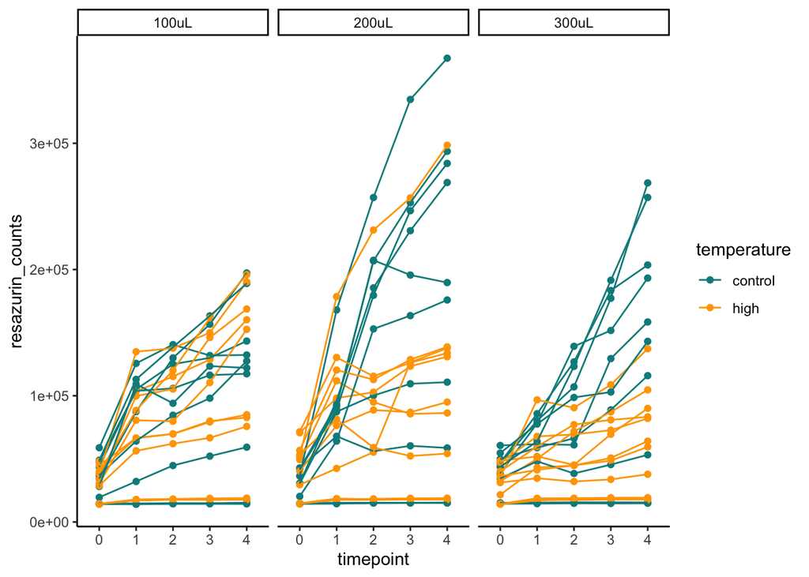

```r
full_data%>%
  ggplot(aes(x=timepoint, y=resazurin_counts, colour=temperature, group=interaction(date, plate, well)))+
  facet_wrap(~volume)+
  geom_point()+
  geom_line()+
  scale_colour_manual(values=c("cyan4", "orange"))+
  theme_classic()
```

Calculate fluorescence at each time point normalized to the starting value at time 0.

```r
full_data<-full_data%>%
  group_by(date, plate, well, temperature, spat_treatment)%>%
  arrange(date, plate, well)%>%
  mutate(fluorescence.norm=resazurin_counts/first(resazurin_counts))
```

Plot again.

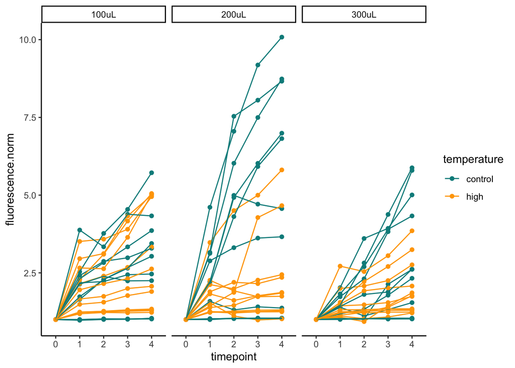

```r
full_data%>%
  ggplot(aes(x=timepoint, y=fluorescence.norm, colour=temperature, group=interaction(date, plate, well)))+
  facet_wrap(~volume)+
  geom_point()+
  geom_line()+
  scale_colour_manual(values=c("cyan4", "orange"))+
  theme_classic()
```

View blanks

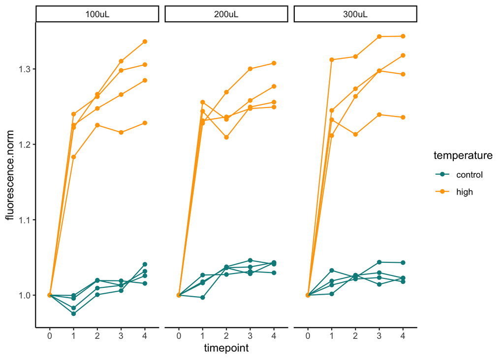

```r
full_data%>%
  filter(type=="blank")%>%
  ggplot(aes(x=timepoint, y=fluorescence.norm, colour=temperature, group=interaction(date, plate, well)))+
  facet_wrap(~volume)+
  geom_point()+
  scale_colour_manual(values=c("cyan4", "orange"))+
  geom_line()+
  theme_classic()
```

There is more of a change in the fluorescence values at high temperature.

Calculate mean change in blank at each time point.

```r
blanks<-full_data%>%
  filter(type=="blank")%>%
  group_by(date, plate, temperature, timepoint, volume)%>%
  summarise(mean_blank=mean(fluorescence.norm));blanks
```

```
## # A tibble: 30 × 6
## # Groups:   date, plate, temperature, timepoint [10]
##    date     plate  temperature timepoint volume mean_blank
##    <chr>    <chr>  <chr>       <chr>     <chr>       <dbl>
##  1 20250114 plate1 control     0         100uL       1
##  2 20250114 plate1 control     0         200uL       1
##  3 20250114 plate1 control     0         300uL       1
##  4 20250114 plate1 control     1         100uL       0.988
##  5 20250114 plate1 control     1         200uL       1.01
##  6 20250114 plate1 control     1         300uL       1.02
##  7 20250114 plate1 control     2         100uL       1.01
##  8 20250114 plate1 control     2         200uL       1.03
##  9 20250114 plate1 control     2         300uL       1.02
## 10 20250114 plate1 control     3         100uL       1.01
## # ℹ 20 more rows
```

View summarized blank data.

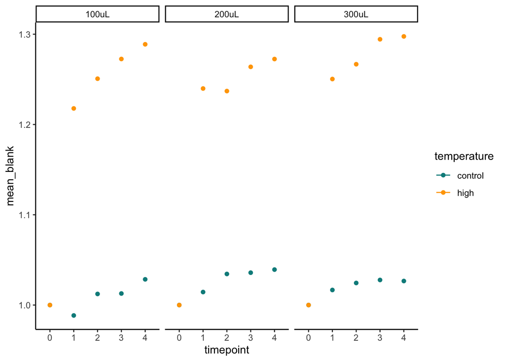

```r
blanks%>%
  ggplot(aes(x=timepoint, y=mean_blank, colour=temperature))+
  facet_wrap(~volume)+
  geom_point()+
  scale_colour_manual(values=c("cyan4", "orange"))+
  geom_line()+
  theme_classic()
```

Subtract blank values from fluorescence values for oysters.

```r
full_data<-left_join(full_data, blanks)

full_data<-full_data%>%
  filter(!type=="blank")%>%
  mutate(value=fluorescence.norm-mean_blank)
```

Plot again.

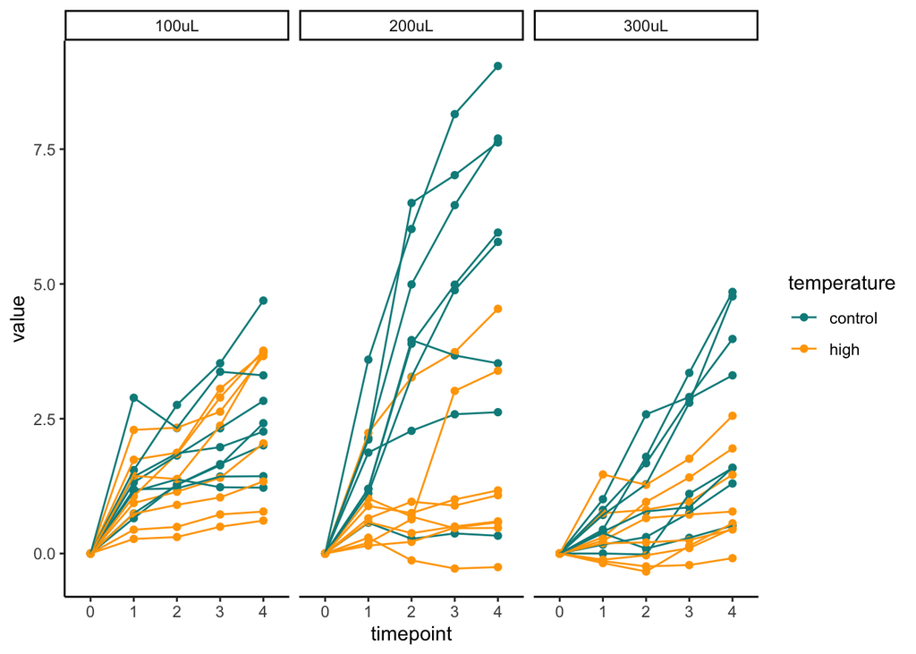

```r
full_data%>%
  ggplot(aes(x=timepoint, y=value, colour=temperature, group=interaction(date, plate, well)))+
  facet_wrap(~volume)+
  geom_point()+
  geom_line()+
  scale_colour_manual(values=c("cyan4", "orange"))+
  theme_classic()
```

Remove unnecessary columns.

```r
full_data<-full_data%>%
  select(!resazurin_counts)%>%
  select(!FileName)%>%
  select(!type)%>%
  select(!fluorescence.norm)%>%
  select(!mean_blank)
```

We will not be doing size normalization for this test.

## Analyze

### Modeling

Plot raw data.

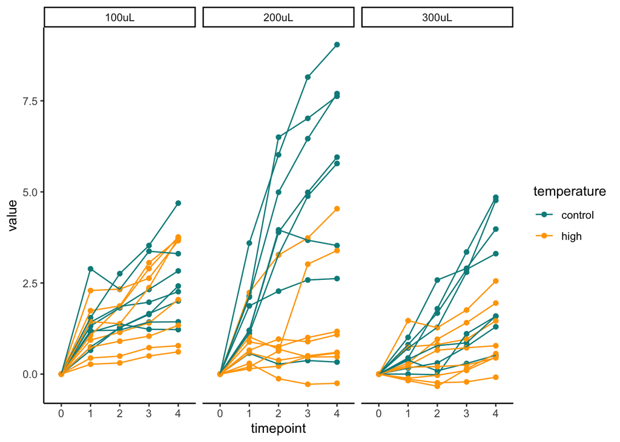

```r
full_data%>%
  ggplot(aes(x=timepoint, y=value, colour=temperature, group=interaction(date, plate, well)))+
  facet_wrap(~volume)+
  geom_point()+
  scale_colour_manual(values=c("cyan4", "orange"))+
  geom_line()+
  theme_classic()
```

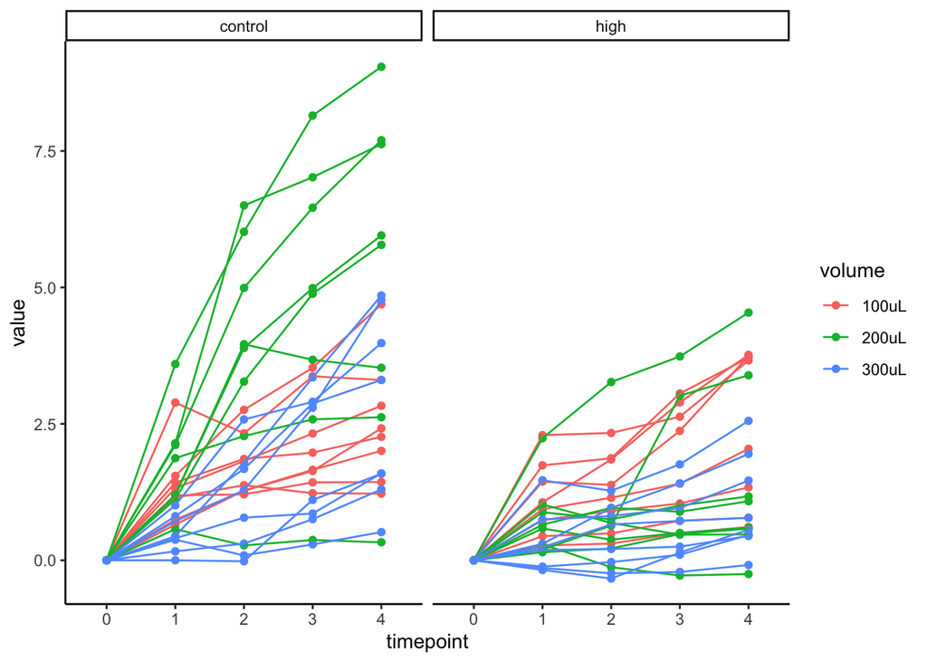

```r
full_data%>%
  ggplot(aes(x=timepoint, y=value, colour=volume, group=interaction(date, plate, well)))+
  facet_wrap(~temperature)+
  geom_point()+
  geom_line()+
  theme_classic()
```

```r
model<-lmer(value ~ timepoint * temperature * volume + (1|plate:well), data=full_data)

summary(model)
```

```
## Linear mixed model fit by REML. t-tests use Satterthwaite's method [
## lmerModLmerTest]
## Formula: value ~ timepoint * temperature * volume + (1 | plate:well)
##    Data: full_data
##
## REML criterion at convergence: 630.4
##
## Scaled residuals:
##     Min      1Q  Median      3Q     Max
## -3.3170 -0.4791 -0.0131  0.4460  3.2073
##
## Random effects:
##  Groups     Name        Variance Std.Dev.
##  plate:well (Intercept) 0.7579   0.8706
##  Residual               0.5856   0.7652
## Number of obs: 240, groups:  plate:well, 48
##
## Fixed effects:
##                                          Estimate Std. Error         df t value
## (Intercept)                             8.024e-14  4.098e-01  9.239e+01   0.000
## timepoint1                              1.364e+00  3.826e-01  1.680e+02   3.566
## timepoint2                              1.737e+00  3.826e-01  1.680e+02   4.539
## timepoint3                              2.143e+00  3.826e-01  1.680e+02   5.602
## timepoint4                              2.521e+00  3.826e-01  1.680e+02   6.589
## temperaturehigh                        -5.845e-14  5.795e-01  9.239e+01   0.000
## volume200uL                            -7.704e-14  5.795e-01  9.239e+01   0.000
## volume300uL                            -7.535e-14  5.795e-01  9.239e+01   0.000
## timepoint1:temperaturehigh             -2.492e-01  5.411e-01  1.680e+02  -0.461
## timepoint2:temperaturehigh             -4.519e-01  5.411e-01  1.680e+02  -0.835
## timepoint3:temperaturehigh             -3.163e-01  5.411e-01  1.680e+02  -0.585
## timepoint4:temperaturehigh             -6.454e-02  5.411e-01  1.680e+02  -0.119
## timepoint1:volume200uL                  3.617e-01  5.411e-01  1.680e+02   0.668
## timepoint2:volume200uL                  2.161e+00  5.411e-01  1.680e+02   3.994
## timepoint3:volume200uL                  2.623e+00  5.411e-01  1.680e+02   4.847
## timepoint4:volume200uL                  2.801e+00  5.411e-01  1.680e+02   5.177
## timepoint1:volume300uL                 -8.746e-01  5.411e-01  1.680e+02  -1.616
## timepoint2:volume300uL                 -6.751e-01  5.411e-01  1.680e+02  -1.248
## timepoint3:volume300uL                 -2.772e-01  5.411e-01  1.680e+02  -0.512
## timepoint4:volume300uL                  2.164e-01  5.411e-01  1.680e+02   0.400
## temperaturehigh:volume200uL             5.290e-14  8.196e-01  9.239e+01   0.000
```

[output cut: 27 more lines]

```
## timepoint2:volume300uL                 0.213890
## timepoint3:volume300uL                 0.609162
## timepoint4:volume300uL                 0.689746
## temperaturehigh:volume200uL            1.000000
## temperaturehigh:volume300uL            1.000000
## timepoint1:temperaturehigh:volume200uL 0.344658
## timepoint2:temperaturehigh:volume200uL 0.000846 ***
## timepoint3:temperaturehigh:volume200uL 4.12e-05 ***
## timepoint4:temperaturehigh:volume200uL 1.57e-06 ***
## timepoint1:temperaturehigh:volume300uL 0.923930
## timepoint2:temperaturehigh:volume300uL 0.796657
## timepoint3:temperaturehigh:volume300uL 0.236423
## timepoint4:temperaturehigh:volume300uL 0.031779 *
## ---
## Signif. codes:  0 '***' 0.001 '**' 0.01 '*' 0.05 '.' 0.1 ' ' 1
```

```r
anova(model)
```

```
## Type III Analysis of Variance Table with Satterthwaite's method
##                               Sum Sq Mean Sq NumDF DenDF F value    Pr(>F)
## timepoint                    193.373  48.343     4   168 82.5596 < 2.2e-16 ***
## temperature                    9.477   9.477     1    42 16.1851 0.0002344 ***
## volume                         7.017   3.508     2    42  5.9914 0.0051389 **
## timepoint:temperature         31.956   7.989     4   168 13.6434 1.182e-09 ***
## timepoint:volume              19.383   2.423     8   168  4.1378 0.0001560 ***
## temperature:volume             6.187   3.094     2    42  5.2833 0.0089814 **
## timepoint:temperature:volume  23.390   2.924     8   168  4.9931 1.445e-05 ***
## ---
## Signif. codes:  0 '***' 0.001 '**' 0.01 '*' 0.05 '.' 0.1 ' ' 1
```

```r
rand(model)
```

```
## ANOVA-like table for random-effects: Single term deletions
##
## Model:
## value ~ timepoint + temperature + volume + (1 | plate:well) + timepoint:temperature + timepoint:volume + temperature:volume + timepoint:temperature:volume
##                  npar  logLik    AIC    LRT Df Pr(>Chisq)
## <none>             32 -315.21 694.41
## (1 | plate:well)   31 -360.17 782.33 89.923  1  < 2.2e-16 ***
## ---
## Signif. codes:  0 '***' 0.001 '**' 0.01 '*' 0.05 '.' 0.1 ' ' 1
```

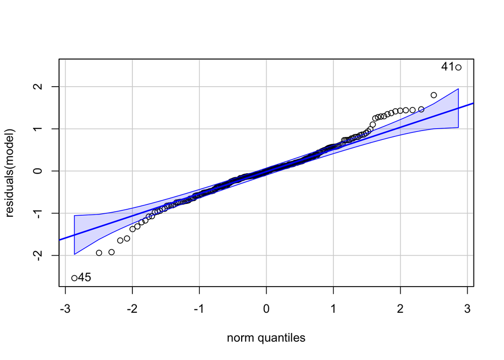

```
## [1] 45 41
```

```r
qqPlot(residuals(model))
```

Plot with individual points with geom smooth lines.

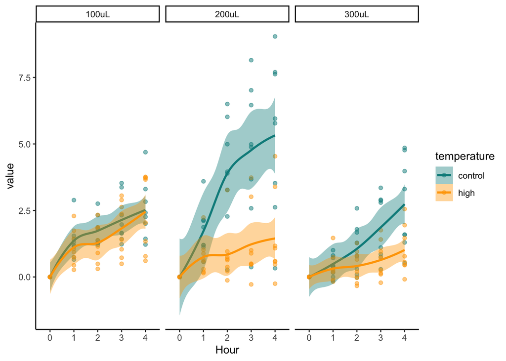

```r
plot1<-full_data%>%

  ggplot(aes(x=timepoint, y=value, color=temperature, fill=temperature))+
  facet_grid(~volume)+
  geom_point(alpha=0.5)+
  geom_smooth(aes(group=temperature))+
  scale_colour_manual(values=c("cyan4", "orange"))+
  scale_fill_manual(values=c("cyan4", "orange"))+
  theme_classic()+
  xlab("Hour");plot1
```

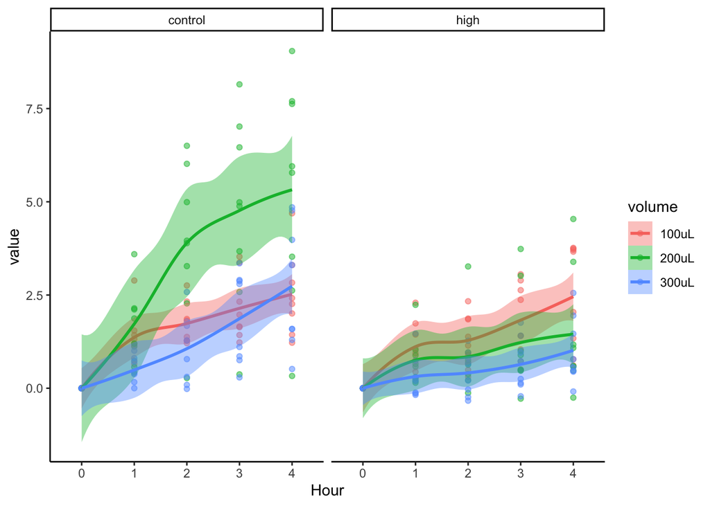

```r
plot1a<-full_data%>%

  ggplot(aes(x=timepoint, y=value, color=volume, fill=volume))+
  facet_grid(~temperature)+
  geom_point(alpha=0.5)+
  geom_smooth(aes(group=volume))+
  theme_classic()+
  xlab("Hour");plot1a
```